# Django ORM Predicates

Lucas Wiman (@lucaswiman)

Counsyl

https://github.com/lucaswiman/orm-predicate-talk

## Django ORM Predicates

[**Django**:](https://www.djangoproject.com/) "The web framework for perfectionists with deadlines."

[**ORM** (Object Relational Mapper)](https://en.wikipedia.org/wiki/Object-relational_mapping): Maps a relational database onto Python objects. (`django.db.models`)

**Predicate**: "a statement that may be true or false depending on the values of its variables."

## Django ORM's goals (AFAICT)

- Make database rows behave like python objects. ("object relational")
- Make querysets behave like python containers (lists, sets), including logically. ("mapper")

## Domain Specific language (DSL)

> *Domain-specific language* (noun): a computer programming language of limited expressiveness focused on a particular domain.

> — *Martin Fowler*

Examples: SQL, regular expressions, CSS, HTML, etc.

Django's ORM provides a DSL for constructing SQL queries.

### Terminology

- `double__underscore__string=thing` is a "lookup"
  - "Lookup" can also refer to `__iexact`, `__in`, etc.
- `QuerySet` is an iterable container class for a SQL query

```
class Order(models.Model):
    pass
class InsuranceClaim(models.Model):
    order = models.OneToOneField(
        'app.InsuranceClaim')
    payer = models.ForeignKey(
        'app.InsurancePayer')
class InsurancePayer(models.Model):
    name = models.TextField()
```

```python
import sqlparse
def pprint_sql(queryset):
    sql = str(queryset.only('pk').query)
    print(sqlparse.format(sql, reindent=True))
```

```python
pprint_sql(Order.objects.filter(claim__payer__name='Aetna'))
```

```
SELECT "app_order"."id"
FROM "app_order"
INNER JOIN "app_insuranceclaim" ON ("app_order"."id" = "app_insuranceclaim"."order_id")
INNER JOIN "app_insurancepayer" ON ("app_insuranceclaim"."payer_id" = "app_insurancepayer"."id")
WHERE "app_insurancepayer"."name" = Aetna
```

## Subtlety: Lookups are trees.

```
MyModel.objects.filter(
    foo__bar__attr1=1,
    foo__bar__attr2=2,
    foo__baz__attr3=3)
```

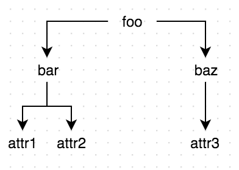

# Django's query DSL is *good*.

[figure not shown]

- It's simple. ("Two underscores between related things.")
- Much easier to use than SQL. Very concise.
- Works pretty well in practice.

# Warts

[figure not shown]

- Weird semantics on joins.
- Confusing casting semantics.
- Weird hodgepodge like `__week_day` lookup.

## `django.db.models.Q` objects

```
some_queryset.filter(foo=1, bar=2)
```

is equivalent to either:

```
some_queryset.filter(Q(foo=1) & Q(bar=2))
some_queryset.filter(Q(foo=1, bar=2))
```

## `django.db.models.Q` objects

```
some_queryset.exclude(foo=1)
```

is equivalent to:

```
some_queryset.filter(~Q(foo=1))
```

# Boolean operations

- `Q(foo=1) & Q(bar=2)` (Conjunction / "and")
- `Q(foo=1) | Q(bar=2)` (Disjunction / "or")
- `~Q(foo=1)` (Negation / "not")

So `Q` objects are *Boolean expression trees of logical predicates*.

# `Q` objects are good for:

- Code reuse (use the same query in different places).
- Literate variable names:

```
has_high_risk_indicator = Q(
    indications__risk_level="HIGH")
has_twin_pregnancy = Q(pregnancy__count__gte=2)
is_covered_Q = has_high_risk_indicator & ~has_twin_pregnancy
def get_covered_people_for_processing():
    return Person.objects.filter(is_covered_Q,
                                 status='UNPROCESSED')
```

# `Q` objects

👍 `Q` objects are *useful*. Use them. 👍

# `Q` objects still suck

They *require* database round trips or code duplication to examine individual records.

# Slow but DRY

```
def is_person_covered_SLOW(person):
      return (Person.objects
              .filter(is_covered_Q, id=person.id)
              .exists())
```

# The database is slow

```
counsyl_product=> SELECT 1 FROM order_order LIMIT 1;
 ?column?
----------
        1
(1 row)

Time: 0.703 ms
```

## Code Duplication

[output not shown]

## Code duplication leads to bugs

```
def is_person_covered_WET(person):
    has_high_risk_indicator = any(
        ind.risk_level == "HIGH"
        for ind in person.indications.all())
    has_twin_pregnancy = person.pregnancy.number >= 2
    return (has_high_risk_indicator and
            not has_twin_pregnancy)
```

## *Boolean expression trees of logical predicates*

Can't Python do that? Python is good at stuff.

# Enter `django-predicate`

- Developed by Preston Holmes (@ptone), https://github.com/django-predicate/django-predicate
- Defines `P` which is Pretty much exactly™ like `Q`  
  but with `__contains__`, `eval` and `filter`.
- `pip install django-predicate`

# Predicate (`P`) objects

- `P` subclasses `Q`, so you can use it in querysets.
- Acts like a container class: `obj in P(foo=bar)`
- Also `P(foo=bar).eval(obj)`
- Also work on nested dicts & ordinary Python objects.

# Example

```
from predicate import P
has_high_risk_indicator = P(
    indications__risk_level="HIGH")
has_twin_pregnancy = P(pregnancy__count__gte=2)
is_covered_P = has_high_risk_indicator & ~has_twin_pregnancy
def is_person_covered_DRY_and_FAST(person):
    return person in is_covered_P

covered_people = Person.objects.filter(is_covered_P)
```

## Example application: Record linkage

# Example application: Record Linkage

**Task:** EOB matching to our database.

- **Algorithm:** Apply a ranked series of match queries, accepting the first to match.
- *e.g.* match on first name, last name, member ID, date of service.
- Nonmatches to a manual queue.
- **Problem:** Querying the database is AND. Fixing nonmatches is OR.

```
PUNCTUATION_AND_SPACES = r'[\s!"#$%&\'()*+,\-./:;<=>?\[\\\]^_`~]'
PUNCTUATION_AND_SPACES_RE = re.compile(PUNCTUATION_AND_SPACES)
REPEATED_PUNCTUATION_AND_SPACES = '%s*' % PUNCTUATION_AND_SPACES

def convert_name_to_fuzzy_regex_string(name):
    name = PUNCTUATION_AND_SPACES_RE.sub('', name)
    name_with_arbitrary_punctuation = REPEATED_PUNCTUATION_AND_SPACES.join(
        name) + REPEATED_PUNCTUATION_AND_SPACES
    return '^%s$' % name_with_arbitrary_punctuation
```

```
name_re = convert_name_to_fuzzy_regex_string(
    eob.patient_first_name)
first_name_predicate =  P(
    insurance_card__patient_first_name__iregex=name_re)
```

```
<span style="color: {% if claim in patient_member_id_predicate %}green{% else %}red{% endif %};">
```

# Open source

- Maintainer wasn't maintaining it.
- Had left an open PR sitting for years.

[figure not shown]

# Open source

- @ptone was very happy when I emailed asking to take over maintenance. 🌈
- Small OSS projects are a great way to get started
- Contributions can come out of day-to-day work
- Great way to learn and build a public resume

# Open source (advice)

- Be obsequiously polite and meticulously detailed
- Submit your best work

# Open Source (advice)

- Do grunt work:
  - improve test suite
  - update documentation/dependencies
- Be very patient: maintainers are volunteers.

# Finding bugs

- Parameterized test suite across:
  - database backends
  - Django versions
  - Use `tox`, `detox`, `tox-travis` and travis-ci.org
- Found bugs with Django 1.8 & sqlite